# Sprint 5 - Choosing Models

## 🚨 This is the continuation of the previous notebook. If this is the first file you are opening during correctiong, considering reviewing the readme file to understand how this project is structured

In the previous files:

- ✅ we have looked at our dataset: we have cleaned it and we have split our data into datasets for each of the sprints and tasks
- ✅ we have created a model that can predict loan elegibility
- ✅ we have created a model that can predict loan grade
- ✅ we have created a model that can predict loan subgrade
- ✅ we have created a model that can predict loan interest rate

In this file:

1. we will select the best performing models and package them for deployment
2. we will also provide some closing thoughts, key takeaways and technicals deep dives into some of the more interesting learnins.

This notebook begins with the same boilerplate as the other ones (imports, basic feature toggles, etc...)

## Imports and initial setup

```python
import ipywidgets as widgets
from IPython.display import display, Markdown, Image, clear_output, HTML
import matplotlib.pyplot as plt
from matplotlib.patches import Rectangle
from itertools import groupby
from collections import defaultdict

import numpy as np
import pandas as pd
import seaborn as sns
from scipy import stats
from scipy.stats import chi2_contingency
import missingno as msno
import pygwalker as pyg
import pygwalker_utils.config as pyg_conf

import statsmodels.api as sm
import optuna

from random import random, seed
import sqlite3 as lite
import logging
import warnings
import ydata_profiling
import iplantuml
import xml.dom.minidom
from datetime import datetime, timedelta
import itertools
from os import path

from sklearn.feature_selection import SelectKBest, f_regression
from sklearn.metrics import (
    ConfusionMatrixDisplay,
    accuracy_score,
    recall_score,
    precision_score,
)
from sklearn.preprocessing import MinMaxScaler, StandardScaler, FunctionTransformer
from sklearn.impute import SimpleImputer
from sklearn.decomposition import PCA
from sklearn.linear_model import LinearRegression, LogisticRegression
from sklearn.model_selection import GridSearchCV
from sklearn.tree import plot_tree
from sklearn.metrics import (
    make_scorer,
    confusion_matrix,
    f1_score,
    PrecisionRecallDisplay,
)
from sklearn.pipeline import Pipeline
from sklearn.impute import KNNImputer
from sklearn.pipeline import make_pipeline
from sklearn.compose import ColumnTransformer
from sklearn.base import BaseEstimator, TransformerMixin
from sklearn.base import clone as clone_pipeline
from sklearn.metrics import classification_report, mean_squared_error

from sklearn.ensemble import RandomForestClassifier, ExtraTreesClassifier
from sklearn.linear_model import LogisticRegression
from xgboost import XGBClassifier
from sklearn.model_selection import GridSearchCV
from sklearn.svm import SVC
import shap
import yellowbrick
from yellowbrick.features import parallel_coordinates
from yellowbrick.regressor import ResidualsPlot

from imblearn.under_sampling import RandomUnderSampler
import joblib

import dask.dataframe as dd
from dask_ml.model_selection import train_test_split as dask_train_test_split

import os
from os import path

from utils import *
from utils import __

from autofeat import AutoFeatRegressor as AFR
from sklearn.model_selection import train_test_split as sklearn_train_test_split
from sklearn.exceptions import DataConversionWarning

import category_encoders as ce

seed(100)
pd.options.display.max_rows = 100
pd.options.display.max_colwidth = 50
util.check("done")
```

```
INFO: Running in offline mode. There might be newer releases available. Please check at https://github.com/Kanaries/pygwalker or https://pypi.org/project/pygwalker.
INFO: Pandas backend loaded 1.5.3
INFO: Numpy backend loaded 1.23.5
INFO: Pyspark backend NOT loaded
INFO: Python backend loaded
```

```
loading utils modules... ✅ completed
configuring autoreload... ✅ completed
✅
```

```python
%reload_ext loans_clean
%reload_ext loans_utils
import loans_clean
from loans_utils import *
```

```python
from imblearn.under_sampling import RandomUnderSampler
```

Let's use `black` to auto-format all our cells so they adhere to PEP8

```python
import lab_black

%reload_ext lab_black
util.patch_nb_black()
# fmt: off
# fmt: on
```

```python
from sklearn import set_config

set_config(transform_output="pandas")
```

```python
logger = util.configure_logging(jupyterlab_level=logging.WARN, file_level=logging.DEBUG)

warnings.filterwarnings("ignore", category=FutureWarning)

# import warnings
# warnings.filterwarnings('error', category=pd.errors.DtypeWarning)
```

```python
def ding(title="Ding!", message="Task completed"):
    """
    this method only works on linux
    """
    for i in range(2):
        !notify-send '{title}' '{message}'
```

## Feature Toggles

Let's also create a simple feature toggle that we can use to skip expensive operations during notebook work (to save myself some time!)

Set it to true if you want to run absolutely everything. Set to false to skip optional steps/exploratory work.

```python
def run_entire_notebook():
    run_all = False
    if not run_all:
        print("skipping optional operation")
    return run_all
```

```python
def perform_split_once_off():
    split_files = False
    if not split_files:
        print("skipping once-off splitting operation")
    return split_files
```

# Selecting the best performing models and deploying them

Here's the plan:

1. We will iterate over all of the Optuna Studies we performed over the last 4 sprints, and pick the best performing model for each of the tasks
2. We will train our models with the training dataset
   - Remeber that we have not used the training dataset, yet!
   - We have used the hyper_ dataset for all of the hyperparameter tuning.
   - In the cases where cross validation was beneficial, we have split the dataset using 5-fold CV and we have used that subset of data
3. We will use the test dataset to assess the performance of our models to see how well the do.
   - Remeber that we have not used the training dataset, yet!
4. Normally, we would then decide if any of the models are good enough to be deployed.
   - This criteria would be defined BEFORE the project starts.
   - However, since this is a learning exercise, we will deploy them all, because the models that we expect to perform poorly will be useful to learn some intermediate app dev skills: (eg. how to use dynamic dispatching of one request and send it to the correct sub model for that specific grade/subgrade).
   - Again. We're only doing this because this is a learning project.
5. We will then build a flask application that can handle HTTP requests
6. We will configure out environment with out Google Cloud Credentials
7. We will deploy the application to GoogleCloud
8. We will test that it works and that it response as expected.
9. We will go get a well deserved ice-cream, and call it a day!
   - If you have made it this far, you also deserve a premium ice cream for all of the work you have put in reviewing this project.
   - If you are ever around, reach out and I will gladly go buy you an icecream!
   - Well done!! You are a hero!

Come on! you can do it.. just 1 more notebook to review together!

We will keep the chatter low on this one 😉

```python
def iterate_files(path):
    return [
        os.path.join(root, file) for root, _, files in os.walk(path) for file in files
    ]
```

```python
def optuna_studies_for_sprint(sprint: int) -> list:
    all_files = iterate_files("optuna_studies")
    return [
        file.replace("optuna_studies/study_", "").replace(".db", "")
        for file in all_files
        if file.startswith(f"optuna_studies/study_sprint{sprint}_")
    ]
```

```python
from collections import defaultdict

best_model_for_sprint = {}
grade_studies = defaultdict(float)
grade_study_name = defaultdict(str)

for sprint in [1, 2, 3, 4]:
    study_names = optuna_studies_for_sprint(sprint)
    study_scores = {
        study_name: optuna_utils.get_study(study_name).best_value
        for study_name in study_names
    }

    if sprint == 3:
        for name, score in study_scores.items():
            grade = name[-1:]
            if score > grade_studies[grade]:
                grade_studies[grade] = score
                grade_study_name[grade] = name
    elif sprint == 4:
        best_model = min(study_scores, key=study_scores.get)
        best_model_for_sprint[sprint] = best_model
    else:
        best_model = max(study_scores, key=study_scores.get)
        best_model_for_sprint[sprint] = best_model


display(best_model_for_sprint)

display(grade_studies)
display(grade_study_name)
```

```
{1: 'sprint1_random_forests',
 2: 'sprint2_xgbclassifier_grade',
 4: 'sprint4_xgbregressor'}
```

```
defaultdict(float,
            {'G': 0.21278362526644914,
             'D': 0.21839171274795674,
             'C': 0.23653365495126857,
             'B': 0.25325848270160084,
             'A': 0.3099367169709643,
             'F': 0.2182148826625771,
             'E': 0.22293620012168436})
```

```
defaultdict(str,
            {'G': 'sprint3_logreg_subgrade_G',
             'D': 'sprint3_xgbclassifier_subgrade_D',
             'C': 'sprint3_xgbclassifier_subgrade_C',
             'B': 'sprint3_xgbclassifier_subgrade_B',
             'A': 'sprint3_xgbclassifier_subgrade_A',
             'F': 'sprint3_xgbclassifier_subgrade_F',
             'E': 'sprint3_xgbclassifier_subgrade_E'})
```

```python
# we were not recording model classes for the first experiments
# we must supply them manually
class_names = {
    1: "sklearn.ensemble.RandomForestClassifier",
    2: "xgboost.XGBClassifier",
    4: None,  # Auto
}

best_models = {}

for sprint, best_study_name in best_model_for_sprint.items():
    k = f"sprint_{sprint}"
    md(f"## SPRINT {sprint} - {k}")
    best_model = optuna_utils.get_best_model(best_study_name, class_names[sprint])
    best_models[k] = best_model
    display(best_model)

md(f"## SPRINT 3 - one model per subgrade")
for grade_letter, best_study_name in grade_study_name.items():
    k = f"sprint_3_grade_{grade_letter}"
    md(f"### GRADE {grade_letter} - {k}")
    best_model = optuna_utils.get_best_model(best_study_name)
    best_models[k] = best_model
    display(best_model)
```

SPRINT 1 - sprint_1

```
RandomForestClassifier(criterion='entropy', max_depth=17, max_features='auto',
                       min_samples_split=9, n_estimators=973)
```

SPRINT 2 - sprint_2

```
XGBClassifier(colsample_bytree=0.3014258683511573, gamma=0.233447232054033,
              learning_rate=0.05059027679042718, max_depth=5,
              min_child_weight=3, n_estimators=970, n_jobs=16,
              reg_alpha=5.814774705594745e-06, subsample=0.9964087517492259)
```

SPRINT 4 - sprint_4

```
XGBRegressor(colsample_bytree=0.866517421189928, gamma=0.000795598354322873,
             learning_rate=0.06535630637210685, max_depth=9, min_child_weight=6,
             n_estimators=240, n_jobs=16, objective='reg:squarederror',
             reg_alpha=0.0014188469069362816, subsample=0.6042397638452961)
```

SPRINT 3 - one model per subgrade

GRADE G - sprint_3_grade_G

```
LogisticRegression(C=45.61646666180672, max_iter=3200, n_jobs=16, penalty='l1',
                   solver='liblinear')
```

GRADE D - sprint_3_grade_D

```
XGBClassifier(colsample_bytree=0.6954325321204093, gamma=0.000312303286966232,
              learning_rate=0.6601695833379714, max_depth=2,
              min_child_weight=10, n_estimators=640, n_jobs=16,
              reg_alpha=6.926612452113561e-06, subsample=0.7925559481077122)
```

GRADE C - sprint_3_grade_C

```
XGBClassifier(colsample_bytree=0.5599133846013241, gamma=1.900695095111514e-06,
              learning_rate=0.07629954326782118, max_depth=7, n_estimators=990,
              n_jobs=16, reg_alpha=0.01480634827570252,
              subsample=0.9866719533000214)
```

GRADE B - sprint_3_grade_B

```
XGBClassifier(colsample_bytree=0.3037421773783818, gamma=0.027932208098915026,
              learning_rate=0.0938800759535869, max_depth=6, min_child_weight=3,
              n_estimators=790, n_jobs=16, reg_alpha=1.3551706451042953e-06,
              subsample=0.6350914376575496)
```

GRADE A - sprint_3_grade_A

```
XGBClassifier(colsample_bytree=0.4399816595149316, gamma=0.00020305021566346452,
              learning_rate=0.05648130226658556, max_depth=9,
              min_child_weight=3, n_estimators=830, n_jobs=16,
              reg_alpha=0.1297223981960177, subsample=0.6589080415145199)
```

GRADE F - sprint_3_grade_F

```
XGBClassifier(colsample_bytree=0.7405300882108294, gamma=0.0018843987670657213,
              learning_rate=0.5372374683159257, max_depth=10, n_estimators=970,
              n_jobs=16, reg_alpha=0.0001349272630045479,
              subsample=0.7316069597977295)
```

GRADE E - sprint_3_grade_E

```
XGBClassifier(colsample_bytree=0.7884767186958485, gamma=2.11983931502611e-05,
              learning_rate=0.2610736676696338, max_depth=9, min_child_weight=9,
              n_estimators=50, n_jobs=16, reg_alpha=2.25910612279861e-06,
              subsample=0.8040547643069279)
```

## Assessing our model's performance

We need to assess our models' performance.

Based on what we saw during each of the sprints, we expect:

- 🟢 Sprint 1 to perform quite well
- 🟡 Sprint 2 to perform relatively well
- 🔴 Sprint 3 (all models) to perform poorly (and to be discarded from deployment to production due to their poor performance)
- 🟢 Sprint 4 to perform well (within the acceptable range of tolerance of $\pm 1$ percentage point)

```python
if run_entire_notebook():
    X_test = dataset_load(Sprint.acceptance, Phase.test, Dataset.X)
    y_test = dataset_load(Sprint.acceptance, Phase.test, Dataset.y)
```

```
skipping optional operation
```

```python
from time import time
```

```python
def train_model(filename):
    X_train = None
    y_train = None

    start = time()
    if filename == "sprint_1":
        print("using", Sprint.acceptance)
        X_train = dataset_load(Sprint.acceptance, Phase.train, Dataset.X)
        y_train = dataset_load(Sprint.acceptance, Phase.train, Dataset.y)
    elif filename == "sprint_2":
        print("using", Sprint.grade)
        X_train = dataset_load(Sprint.grade, Phase.train, Dataset.X)
        y_train = dataset_load(Sprint.grade, Phase.train, Dataset.y)
    elif filename in [
        "sprint_3_grade_A",
        "sprint_3_grade_B",
        "sprint_3_grade_C",
        "sprint_3_grade_D",
        "sprint_3_grade_E",
        "sprint_3_grade_F",
        "sprint_3_grade_G",
    ]:
        print("using", Sprint.subgrade)
        X_train = dataset_load(Sprint.subgrade, Phase.train, Dataset.X)
        y_train = dataset_load(Sprint.subgrade, Phase.train, Dataset.y)

        grade = filename[-1:]
        X_train["grade"] = y_train.str.get(0)
        X_train = X_train.groupby("grade").get_group(grade).drop(columns="grade")
        y_train = y_train.loc[X_train.index]

    elif filename == "sprint_4":
        print("using", Sprint.interest)
        X_train = dataset_load(Sprint.interest, Phase.train, Dataset.X)
        y_train = dataset_load(Sprint.interest, Phase.train, Dataset.y)
    else:
        raise ValueError(f"invalid filename {filename}")

    print(f"starting {filename}", X_train.shape, y_train.shape)
    n = min(200_000, X_train.shape[0])
    print(f"using {n} rows")
    X, y = pandas_utils.xy_sample(X_train, y_train, n=n)

    model.fit(X, y)
    end = time()
    print(n, end - start)
    joblib.dump(model, f"models/{filename}.model")
```

```python
if run_entire_notebook():
    for filename, model in best_models.items():
        train_model(filename)
    ding()
```

```
skipping optional operation
```

The models have been trained and exported to disk!

[figure not shown]

# Visualizing model performance

Let's visualize how these models perform

```python
def summary_confusion_matrix(sprint: Sprint, model_filename: str, ax=None):
    if not ax:
        ax = plt.gca()
    X = dataset_load(sprint, Phase.test, Dataset.X)
    y = dataset_load(sprint, Phase.test, Dataset.y)

    X_test, expected = pandas_utils.xy_sample(X, y, n=100_000)

    model = joblib.load(f"models/{model_filename}.model")
    predicted = model.predict(X_test)
    cm = yellowbrick.classifier.ConfusionMatrix(
        model, percent=True, is_fitted=True, ax=ax
    )
    cm.score(X_test, expected)
    return ax
```

```python
def summary_residuals_plot(sprint: Sprint, model_filename: str, ax=None):
    if not ax:
        ax = plt.gca()
    X = dataset_load(sprint, Phase.test, Dataset.X)
    y = dataset_load(sprint, Phase.test, Dataset.y)

    X_test, expected = pandas_utils.xy_sample(X, y, n=100_000)

    model = joblib.load(f"models/{model_filename}.model")
    predicted = model.predict(X_test)
    rp = yellowbrick.regressor.ResidualsPlot(model, percent=True, is_fitted=True, ax=ax)
    rp.score(X_test, expected)
    return ax
```

```
could not determine class_counts_ from previously fitted classifier
```

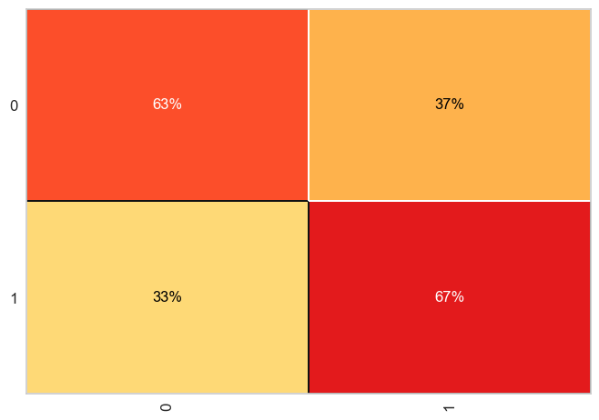

```python
@run
@cached_chart(1)
def summary_confusion_matrix_sprint1():
    return summary_confusion_matrix(Sprint.acceptance, "sprint_1")
```

```
could not determine class_counts_ from previously fitted classifier
```

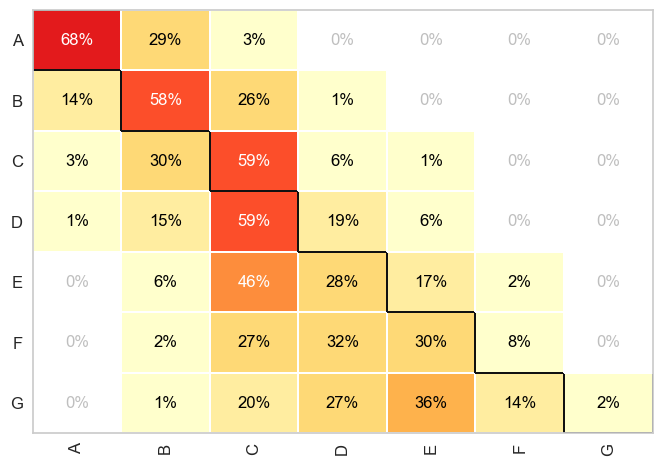

```python
@run
@cached_chart(1)
def summary_confusion_matrix_sprint2():
    return summary_confusion_matrix(Sprint.grade, "sprint_2")
```

```
Loading from cache [./cached/charts/summary_confusion_matrix_sprint3.png]
```

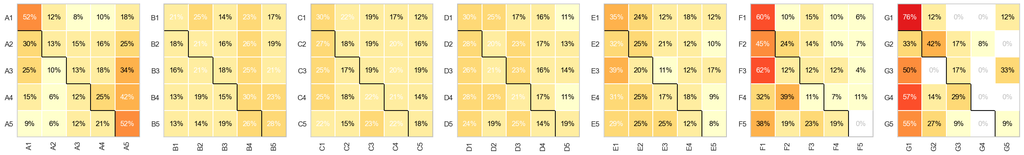

```python
@run
@cached_chart()
def summary_confusion_matrix_sprint3():
    fig, ax = plt.subplots(1, 7, figsize=(30, 4))
    summary_confusion_matrix(Sprint.subgrade, "sprint_3_grade_A", ax=ax[0])
    summary_confusion_matrix(Sprint.subgrade, "sprint_3_grade_B", ax=ax[1])
    summary_confusion_matrix(Sprint.subgrade, "sprint_3_grade_C", ax=ax[2])
    summary_confusion_matrix(Sprint.subgrade, "sprint_3_grade_D", ax=ax[3])
    summary_confusion_matrix(Sprint.subgrade, "sprint_3_grade_E", ax=ax[4])
    summary_confusion_matrix(Sprint.subgrade, "sprint_3_grade_F", ax=ax[5])
    summary_confusion_matrix(Sprint.subgrade, "sprint_3_grade_G", ax=ax[6])
    return fig
```

[figure not shown]

```python
@run
@cached_chart()
def summary_confusion_matrix_sprint4():
    return summary_residuals_plot(Sprint.interest, "sprint_4")
```

Reminder: This plot does not show training data because it is using a pre-trained model

## Thoughts on model performance

| What we expected | Actual performance | Thoughts |
| --- | --- | --- |
| 🟢 | 🟢 | The model behaved how we imagined, getting similar results to the ones we saw in Sprint 1 |
| 🟡 | 🟡 | Same (for sprint 2) |
| 🔴 | 🔴 | Same (for sprint 3) |
| 🟢 | 🟡 | The model is behaving noticeably worse than what we saw in Sprint 4. It could be due to some overfitting. I doubt it is caused by poor data shuffling. Each of the splits was fairly well randomized |

# Creating the web app

This is not the first time we create an app that loads models and uses them to predict.

However, it IS the first time we have models exceeding 700MB that need to be deployed.

Since these cannot be deployed to Google Cloud Engine, they will be stored in a bucket, and fetched at runtime (and cached!) when needed.

Developing this app is not too hard. The only new thing was this:

yes, these values (bucketname) could be parameterized... but some small things were rushed due to deadlines.

[figure not shown]

Testing the app running locally:

[figure not shown]

## Deploying to Google Cloud

The last part is the actual deployment to google cloud

### Install the docker image

We will deploy our app using the Google Cloud CLI, but we don't want to install it bare on our laptop.

This docker container comes ready and preconfigured and it will allow us to deploy without getting our laptop dirty and full of google libraries.

The steps can be found here: https://cloud.google.com/sdk/docs/downloads-docker

```
(base) edu@flex:~$ docker pull gcr.io/google.com/cloudsdktool/google-cloud-cli:latest
latest: Pulling from google.com/cloudsdktool/google-cloud-cli
5dea071bb978: Pull complete
dbec39f4bdb7: Pull complete
838ee69e3b31: Pull complete
ce29b385749f: Pull complete
0b683beed50e: Pull complete
42926f8ae381: Pull complete
5dd56a650516: Pull complete
Digest: sha256:ca1fd6ad5dd411c822b1f18d445e15764d6477cfaddbd92f0e776a7520e2b33d
Status: Downloaded newer image for gcr.io/google.com/cloudsdktool/google-cloud-cli:latest
gcr.io/google.com/cloudsdktool/google-cloud-cli:latest
(base) edu@flex:~$
```

Everything looks good:

```
(base) edu@flex:~$ docker run --rm gcr.io/google.com/cloudsdktool/google-cloud-cli:latest gcloud version
Google Cloud SDK 445.0.0
alpha 2023.09.01
app-engine-go 1.9.75
app-engine-java 2.0.17
app-engine-python 1.9.105
app-engine-python-extras 1.9.101
beta 2023.09.01
bigtable
bq 2.0.97
bundled-python3-unix 3.9.16
cbt 0.16.1
cloud-datastore-emulator 2.3.1
cloud-firestore-emulator 1.18.1
cloud-spanner-emulator 1.5.9
core 2023.09.01
gcloud-crc32c 1.0.0
gke-gcloud-auth-plugin 0.5.5
gsutil 5.25
kpt 1.0.0-beta.43
local-extract 1.5.9
pubsub-emulator 0.8.6
```

After running this: `gcloud auth login`

We get a osur secret token

[figure not shown]

```
(flask) edu@flex:~$ gcloud_docker config list
[core]
account = edu.xxxxxxxxxxxxx@gmail.com
disable_usage_reporting = True
project = xxxxxxxxx-xxxxxx-398xxx

Your active configuration is: [default]
(flask) edu@flex:~$
```

Let's create some bucket for our models

```
(flask) edu@flex:~$ gcloud_docker storage buckets create gs://turing-college-2023-edu-loans-sprint11  --project gifted-harmony-398713
Creating gs://turing-college-2023-edu-loans-sprint11/...

(flask) edu@flex:~$
```

[figure not shown]

Some instructions that proved useful and I will keep here for future reference:

```
docker run --rm -ti --volumes-from gcloud-config gcr.io/google.com/cloudsdktool/cloud-sdk gcloud config list

docker run --rm -ti --volumes-from gcloud-config gcr.io/google.com/cloudsdktool/cloud-sdk gcloud storage buckets create gs://turing-college-2023-edu-loans-sprint11  --project gifted-harmony-398713

do`ker run --rm -ti --volumes-from gcloud-config -v /home/edu/PycharmProjects/pythonProject/flask:/app gcr.io/google.com/cloudsdktool/cloud-sdk gcloud app deploy /app/app.yaml
```

## Checking that the app actually runs.

We can use jupyter to check that the apps run properly.. Here, check it out!

```python
import http.client
import json

conn = http.client.HTTPSConnection("gifted-harmony-398713.ew.r.appspot.com")
payload = json.dumps(
    {
        "mths_since_last_delinq": 16,
        "mths_since_last_record": 0,
        "loan_amnt": 25000,
        "term": 0,
        "emp_length": 2,
        "home_ownership_own": 0,
        "home_ownership_mortgage": 1,
        "home_ownership_other": 0,
        "annual_inc": 129000,
        "verification_status": 0,
        "pymnt_plan": 0,
        "purpose_debt": 1,
        "purpose_improve": 0,
        "purpose_other": 0,
        "purpose_emergency": 0,
        "purpose_pleasure": 0,
        "dti": 19.81,
        "delinq_2yrs": 2,
        "fico_range_low": 705,
        "inq_last_6mths": 0,
        "open_acc": 19,
        "pub_rec": 0,
        "revol_bal": 32145,
        "revol_util": 40.9,
        "total_acc": 37,
        "initial_list_status": 0,
        "tot_coll_amt": 0,
        "tot_cur_bal": 604979,
        "total_rev_hi_lim": 91100,
        "acc_open_past_24mths": 6,
        "bc_open_to_buy": 1016,
        "chargeoff_within_12_mths": 0,
        "delinq_amnt": 0,
        "mo_sin_old_il_acct": 125,
        "mo_sin_old_rev_tl_op": 239,
        "mo_sin_rcnt_rev_tl_op": 10,
        "mo_sin_rcnt_tl": 10,
        "mort_acc": 3,
        "mths_since_recent_bc": 15,
        "mths_since_recent_inq": 10,
        "num_accts_ever_120_pd": 0,
        "num_actv_bc_tl": 2,
        "num_bc_tl": 6,
        "num_il_tl": 7,
        "num_tl_120dpd_2m": 0,
        "num_tl_30dpd": 0,
        "num_tl_90g_dpd_24m": 0,
        "num_tl_op_past_12m": 2,
        "pct_tl_nvr_dlq": 91.9,
        "pub_rec_bankruptcies": 0,
        "tax_liens": 0,
        "total_bal_ex_mort": 123237,
        "disbursement_method": 1,
    }
)
headers = {"Content-Type": "application/json"}
conn.request("POST", "/predict/grade", payload, headers)
res = conn.getresponse()
data = res.read()
response = data.decode("utf-8")
response
```

```
'{"original_request":{"acc_open_past_24mths":6,"annual_inc":129000,"bc_open_to_buy":1016,"chargeoff_within_12_mths":0,"delinq_2yrs":2,"delinq_amnt":0,"disbursement_method":1,"dti":19.81,"emp_length":2,"fico_range_low":705,"home_ownership_mortgage":1,"home_ownership_other":0,"home_ownership_own":0,"i…
```

```python
json_response = json.loads(response)
display(json_response["prediction_type"])
display(json_response["prediction_result"])
```

```
'GRADE'
```

```
{'confidence': 0.4459541141986847, 'prediction': 'A'}
```

# No more "Next steps"!

This is the end of sprint 5.

In this sprint, we have have prepared the best models, we have created an app using flask, and we have deployed it to google cloud platform.

I am leaving here some more "lessons learned" and crazy stories... You know, just in case you decided to correct this project on a saturday morning and want to spend more time with my thoughts!

# Technical Deep dive and lessons learned

This section contains "lessons learned" beyond the scope of the project (by trying some extra challenges)

I decided to keep it short and only share the crazier stories.

## About highly-concurrenct code, memory management and SIGSEGV (Segmentation Fault)

You will notice that during Sprint 2, we only use 14k rows in the code for parallelizing Optuna optimizations.

*(actually, that might no longer be the case: I wrote this one crazy night at 4AM and, even though the bug described here was real, I have never again been able to replicate it... so it is possible that in the end I decided to hyper-tune the model using more than 14k)...*

Anwyay... back to the story: remember, it's 4AM on a crazy August night:

We have noticed that if the dataset we use for this is above 5MB (not 4.9MB, but 5MB or above), we get our subprocesses killed with SIGSEGV (Segmentation fault) = exit code 11

This was tested with the following row ranges: From 0 to 14k: ✅ From 0 to 14.5k: ✅ From 0 to 15k: ❌ From 14k to 15k: ✅

From 10k to 24k: ✅ From 10k to 24.5k: ✅ From 10k to 25k: ❌

- 🟨🟨🟨🟨🟨🟨🟨🟨🟨🟨🟨🟨🟨🟨⬛⬛⬛⬛⬛⬛⬛⬛⬛⬛⬛⬛⬛⬛⬛⬛ - ✅
- 🟨🟨🟨🟨🟨🟨🟨🟨🟨🟨🟨🟨🟨🟨🟨⬛⬛⬛⬛⬛⬛⬛⬛⬛⬛⬛⬛⬛⬛⬛ - ❌
- ⬛⬛⬛⬛⬛⬛⬛⬛⬛⬛🟨🟨🟨🟨🟨⬛⬛⬛⬛⬛⬛⬛⬛⬛⬛⬛⬛⬛⬛⬛ - ✅
- ⬛⬛⬛⬛⬛⬛⬛⬛⬛⬛⬛⬛⬛⬛🟨⬛⬛⬛⬛⬛⬛⬛⬛⬛⬛⬛⬛⬛⬛⬛ - ✅
- ⬛⬛⬛⬛⬛⬛⬛⬛⬛⬛🟨🟨🟨🟨🟨🟨🟨🟨🟨🟨🟨🟨🟨🟨⬛⬛⬛⬛⬛⬛ - ✅
- ⬛⬛⬛⬛⬛⬛⬛⬛⬛⬛🟨🟨🟨🟨🟨🟨🟨🟨🟨🟨🟨🟨🟨🟨🟨⬛⬛⬛⬛⬛ - ❌
- and many others that I no longer remember, but they all consistently behaved the same way. It was not actually the number of rows but the size of the memory used.

This drove me to the conclusion that the issue was not "bad data" hiding at row 15001, but that it was the amount of memory.

This was an issue wven when using `Manager.list()` to handle/wrap objects so each process gets its own individual copy.

After so many rounds of testing, debugging, logging, inspecting and attempting to fix it various workarounds (timing, deep copies of data, avoiding accidental data sharing from different processes), I found no solution that allowed me to use the entire dataset.

Fortunately, it was not necessary to use the entire dataset for tuning. Even just 14k was plenty to provide a farily good f1 score and pretty good performance.

### PS thoughts

As I reflect on it now, there were other options I could have tried (if I suspected that the issue was sharing data across subprocesses). One of the things I could have tried would be to use a different chunk of the dataset for each of the processes...

I'll list this a "things that I will remember for next project!". It might not result in "using the entire dataset for tuning", because each process will only use a subset.. but, hey! If it works for random forests... why wouldn't it works for Optuna! 🤔

### What are segmentation faults

If you ever notice that the processes you are spinning up fail to complete and you see this number (-11) when you inspect their return codes, you know you have a problem with the OS killing the processes because they tried to access data that they were not allowed to access.

[figure not shown]

https://en.wikipedia.org/wiki/Segmentation_fault

> An exit code of -11 usually indicates a segmentation fault (SIGSEGV) in Linux. A segmentation fault is an error that occurs when a program tries to access memory that it is not allowed to access, such as trying to write to read-only memory or trying to read or write outside the bounds of an array. This can be caused by a variety of issues, such as programming errors, hardware faults, or issues with the operating system or libraries.

> To diagnose the issue, you may want to check the logs or output of the subprocesses to see if there are any error messages or stack traces that can provide more information about the cause of the segmentation fault. You can also try running the subprocesses under a debugger, such as gdb, to get more detailed information about the state of the program at the time of the crash.

### One of the many attempts to fix it

#### Understanding what was happening

One of the hypothesis I had when debugging this was that maybe this was being caused by shared data across processes (instead of copies)

A bit of logging demonstrated that each of the processes was accessing the same memory locations.

[figure not shown]

The solution involved creating deep copies of the objects.

#### Trying to fix it using deep copies of the data

Process Explorer shows the moment 9 subprocesses are started (the initial spike in CPU for a few seconds that impacts all cores), and then a bunch of squiggly lines as the processes become free and start a new round.

The main concern was that making multiple copies of the data (so each process has its own independent copy) might be too much, but the small bump in memory seems very reasonable and makes this approach possible.

[figure not shown]

Despite this (one of the attempts at using copies of the data), the solution did not scale beyond 15k rows

#### Final plot twist

Turns out... the very next day, after a healthy reboot, everything started working again...

[figure not shown]

After spending 3h last night debugging some crazy obscure (yet **very consistent**) behaviour... after a system reboot, today everything works, even when we cross the 15k threshold!

The process completed successfully:

[figure not shown]

It could be some flaky thing, or even some of the updates I applied (before rebooting)...

[figure not shown]

we will never know, but I am happy I got to learn so much about writing highly concurrent code, and that this proves that it was not an issue with the data or (more importantly) with my code.

Remember that it cannot be the data, because that has been already split and cleaned as a once-off task, so the data is the same no matter how many times I reboot the PC.

## About Data Splitting

I learned that it's hard to split data properly.

This took several attempts and back and forth! Advance planning and foresight are for sure a set of skills I will use in the future.

[output not shown]

## About Hyperparameter Tuning approaches

Optuna seems like a powerful tool, but I often wondered about ways to improve things even more.

The idea of doing a 2-phased approach to hyperparameter tuning crossed my mind a few times.

It seemed reasonable to do a "quick scan" of the search space (fast, with 10% of the data), and follow by doing an "in depth" optimization of the hyperparameters.

Unfortunately, this did not prove to be useful.. The Analysis below shows that, even though the two pass improves over time (the second slow pass is better than the first fast one), they are still far from the better performing approach (a single pass with all of the data).

The time taken on the fast pass was a really good start, but not enough to justify losing 10% to 20% of the performance.

Data extracted from Optuna logs and sqlite database. Only the intermediate scores were used, not the averaged ones:

```
14 = intermediate score = 0.4955272034022584 on step 1 - scores [0.4955272034022584]
0 = intermediate score = 0.49970670186244315 on step 1 - scores [0.49970670186244315]
5 = intermediate score = 0.4417069951605807 on step 1 - scores [0.4417069951605807]
4 = intermediate score = 0.47528963191083734 on step 1 - scores [0.47528963191083734]
7 = intermediate score = 0.49501393166153396 on step 1 - scores [0.49501393166153396]
14 = intermediate score = 0.49479395805836635 on step 2 - scores [0.4955272034022584, 0.49406071271447427]
0 = intermediate score = 0.5007332453438921 on step 2 - scores [0.49970670186244315, 0.501759788825341]
2 = intermediate score = 0.47528963191083734 on step 1 - scores [0.47528963191083734]
1 = intermediate score = 0.477636017011292 on step 1 - scores [0.477636017011292]
12 = intermediate score = 0.48166886640269835 on step 1 - scores [0.48166886640269835]
14 = intermediate score = 0.49342523341643446 on step 3 - scores [0.4955272034022584, 0.49406071271447427, 0.49068778413257075]
10 = intermediate score = 0.4608446986361637 on step 1 - scores [0.4608446986361637]
5 = intermediate score = 0.44335679718433785 on step 2 - scores [0.4417069951605807, 0.44500659920809504]
8 = intermediate score = 0.48174219093708753 on step 1 - scores [0.48174219093708753]
6 = intermediate score = 0.45497873588502713 on step 1 - scores [0.45497873588502713]
```

```python
# fmt: off
single_round_slow = [
    0.4955272034022584,    0.49970670186244315,    0.4417069951605807,    0.47528963191083734,    0.49501393166153396,
    0.4955272034022584,    0.49406071271447427,    0.49970670186244315,    0.501759788825341,    0.47528963191083734,
    0.477636017011292,    0.48166886640269835,    0.4955272034022584,    0.49406071271447427,    0.49068778413257075,
    0.4608446986361637,    0.4417069951605807,    0.44500659920809504,    0.48174219093708753,    0.45497873588502713,
]
```

```python
# fmt: off
two_rounds_first_round_fast = [
    0.41,    0.41500000000000004,    0.379,    0.388,    0.42000000000000004,    0.40750000000000003,    0.422,    0.43099999999999994,
    0.44299999999999995,    0.41000000000000003,    0.38499999999999995,    0.415,    0.39249999999999996,    0.39,    0.405,
    0.39,    0.395,    0.405,    0.38499999999999995,    0.38499999999999995,    0.42800000000000005,
    0.39,    0.36,    0.37,    0.38,    0.39,    0.37,    0.38,    0.36,    0.42125,    0.42799999999999994,
    0.35,    0.35,    0.42000000000000004,    0.38,    0.42899999999999994,    0.36499999999999994,    0.42400000000000004,    0.38,
    0.35,    0.42400000000000004,    0.38499999999999995,    0.39,    0.4173999120105587,    0.4163367062619152,    0.41974629711101336,
    0.4179865082856724,    0.42651048540841763,
]
```

```python
# fmt: off
two_rounds_second_round_slow = [
    0.4447133010705382,    0.44251356503886197,    0.44500659920809504,    0.44940607127144744,    0.45057926382167474,    0.42550227306056604,    0.42509898812142544,
    0.4258688957325121,    0.42651048540841763,    0.4419269687637484,    0.44390673119225693,    0.4491860976682798,    0.4506525883560639,    0.4455931954832087,
    0.45057926382167474,    0.45230239037982106,    0.4477196069804957,    0.44922275993547445,    0.44874615046194455,
    0.4494060712714474,
    0.4223493180818302,
    0.4214327614019651,
    0.43188150755242705,
    0.4289851884440534,
]
```

```python
third_run = [ 0.41610206775186975,0.45713447719606987,0.4975362956445227,0.49533655961284645,0.46113799677372047,0.4352910984015252
,0.4727379381140929,0.48507112479835757,0.4659040915090189,0.4590115852764335,0.4607347118345798,0.45813169086376304
,0.4794544654641443,0.47145231461113557,0.4992667546561079,0.47039521924035776,0.47279659774160426,0.5008505645989149
,0.5006599208095028,0.49991201055873297,0.4977122745270567,0.48716820648188885,0.48518844405338024,0.4802023757149142
,0.4875348291538349,0.4877548027570025,0.49175098988121424,0.4785892359583517,0.4977416043408125,0.49112773133890597
,0.4865816102067752,0.4990907757735738,0.4942806863176419,0.4963777680011733,0.49771227452705674,0.4998093562105881
,0.49277753336266317,0.4788825340959085,0.4848218213814342,0.4863616366036076,0.4854084176565479,0.48518844405338024
,0.47961577943980055,0.4984748496847045,0.5042088282739405,0.5017304590115853,0.49503226279513124,0.5006452559026251
,0.49951605807303123,0.5008798944126704,0.498240211174659,0.5017157941047075,0.49972136676932105,0.5016717993840738
,0.49252089749230094,0.492887520164247,0.49831353570904824

]
```

[figure not shown]

```python
plt.title("Optuna Performance (2 rounds vs 1 round)")
sns.kdeplot(two_rounds_first_round_fast, color="#ade8f4")
sns.kdeplot(two_rounds_second_round_slow, color="#0077b6")
sns.kdeplot(single_round_slow, color="#bb3e03")
sns.kdeplot(third_run, color="black")
plt.legend(
    ["two_rounds_first_round_fast", "two_rounds_second_round_slow", "single_round_slow_", "final_slow_run_uninterrupted"]
)
```

```python
_, pvalue = stats.ttest_ind(two_rounds_second_round_slow, single_round_slow)
pvalue
```

```
3.0013045221190067e-10
```

It's pretty clear that the 2-phased approach produces **worse results**. So in the end, I decided to use 1 slow round instead of 2 fast ones.

### About Model Complexity and detecting bugs

```
starting sprint_3_grade_G
'n_jobs' > 1 does not have any effect when 'solver' is set to 'liblinear'. Got 'n_jobs' = 16.
8000 0.30658483505249023
starting sprint_3_grade_D
8000 2.9675545692443848
starting sprint_3_grade_C
8000 11.158004522323608
starting sprint_3_grade_B
8000 8.578343868255615
starting sprint_3_grade_A
8000 7.1215293407440186
starting sprint_3_grade_F
8000 5.686566591262817
starting sprint_3_grade_E
8000 0.6942386627197266
```

Something interesting was seeing how the different models for predicting subgrade behaved differently.

Of particular interest is the numerous differences between model for grade B and model for grade C:

- Remember: The amount of data for grade B and C is very similar and they are both the most common grades, by far.

Despite this, there were numerous differences to highlight:

- The model for grade C was a lot smaller on disk, but took longer to train (though not a lot)
- The model for grade B was a lot larger, but was faster to train
  - The size for the model was the expected size if we were to extrapolate when comparing to model A

This might point to interesting patterns in the data that the model might have learned.

[figure not shown]

PS: Plot twist! At the end I realized that this difference in size was because I had accidentally trained the model to predict the WRONG target variable.. so it was going into super-overfitting territory, and trying to learn all of the crazy edge cases.

After fixing this and retraining, the model was no longer 5.7GB! 😎

# Conclusions

## Executive Summary

This project focuses on the loans dataset available from Kaggle.

It provides numerous challenges:

- A really large dataset (+2GB)
- A great opportunity to improve data wrangling and cleaning skills. The vast majority of effort was on data cleaning, getting familiar with the data and finding weird patterns and spots to clean.
- A steep learning curve:
  - The 4 challenges come in increasing difficulty and require more and more refined skills to not get trapped in the mud.
- Bonus points if you have a PC with limited resources!

Overall, I am happy I got to do it, but what I am really happy about is.. about finishing it! (no doubt you are also happy to be finishing this correction)

## On Growth

It has been, no doubt, a challenge I won't forget easily, but I'm quite satisfied with the results.

It has been a nightmare to get everything to the level of quality that I wanted. I do not regret having gone into unexplored territory (learning optuna in depth, or how to write (and debug) highly concurrent code in linux AND windows, come to mind), even if it has meant it took me a bit longer to complete it.

I hope you had as much fun reading this I as I did figuring things out! :)

## Future improvements

- I heard it's possible to use GPUs for XGBoost - https://xgboost.readthedocs.io/en/stable/gpu/index.html
  - My laptop has no discrete GPU, but it would be nice to explore in the future on a PC with a GPU and comapre the performance boost that it gives.